```python
import pylab as pl
import healpy as hp
from sklearn import preprocessing
from sklearn.neighbors import DistanceMetric
from sklearn.metrics import pairwise_distances
from sklearn.metrics.pairwise import pairwise_kernels
from sklearn.cluster import SpectralClustering
from sklearn.cluster import AgglomerativeClustering
from scipy.interpolate import interp1d
from pylab import cm
from clustering_utils import  (
    smooth_and_rotate_map,
    intracluster_distance,
    hellinger_distance,
    setup_features,
    get_K_opt,
    )
cmap = cm.get_cmap('RdYlBu')
cmap.set_under('w')
cmap2 = cm.get_cmap('tab20b')
cmap2.set_under('w')

import warnings; warnings.simplefilter('ignore')
%matplotlib inline
```

```python
from IPython.display import HTML

HTML('''<script>
code_show=true;
function code_toggle() {
 if (code_show){
 $('div.input').hide();
 } else {
 $('div.input').show();
 }
 code_show = !code_show
}
$( document ).ready(code_toggle);
</script>
<form action="javascript:code_toggle()"><input type="submit" value="Click here to toggle on/off the raw code."></form>''')
```

# Alternative metrics to predict Foreground spectral index variations

Giuseppe Puglisi (Stanford) - 10/31/2019

Recently there has been mail offline discussions about building up a recipe in order to choose where best to observe and avoid foregrounds.

The common figures of merit used so far have been polarization amplitude ([post](https://cmb-s4.org/wiki/index.php/Deeper_SAT_from_Chile) ) and the $r$-equivalent maps ([post](http://bicep.rc.fas.harvard.edu/CMB-S4/analysis_logbook/20180425_r_equivalent_maps) )

In this post, I present a different methodology which might be more data driven than the metrics adopted so far. In particular, I've focused on **Clustering methodologies**, to alternatively define and identify patches accordingly to spectral index variations. Clustering techniques can be used for this goal, since they group data instances into subsets in such a manner that similar instances are grouped together, while different instances belong to different groups (or clusters). To quantify how *similar* or *close* two instance are, a **similarity measure** ( or equivalently **distance metric** ) needs to be define accordingly to the type of data we use.

There is a large variety of clustering methods as well as distances in the literature (e.g. the [documentation page](https://scikit-learn.org/stable/modules/clustering.html) of scikit-learn) , I've tested a couple of them and found that **Hierarchical Clustering** does the best job. The Hierarchical clustering (see more details in [VanderPlas et al.](https://arxiv.org/pdf/1411.5039.pdf) sect.IV ) is mostly adopted to finds clusters at all scales and can be approached as an *agglomerative* (bottom-up) procedure, all clusters are built by progressively merging nearest pairs.

Here I present preliminary results applying the Hierarchical Clustering to $\beta_d$ maps from the [PySM template](https://github.com/bthorne93/PySM_public/blob/master/pysm/template/dust_beta.fits) and from the [GNILC Planck release](http://pla.esac.esa.int/pla/aio/product-action?MAP.MAP_ID=COM_CompMap_Dust-GNILC-Model-Spectral-Index_2048_R2.00.fits).

## Map-preprocessing

- Convolve maps with a $6 $ deg beam and rotate them from Galactic to Equatorial
- Degrade maps at `nside=32`

## Similarity for Planck Maps

When dealing with Planck maps, uncertainties need to be taken into account in defining the similarity between two pixels. Assuming that each value of $\beta_d$ is normal distributed with $\sigma= \sigma(\beta_d)$ we can estimate the continuous probability distribution, $ \mathcal{P} \sim N( {\beta }_d ,\sigma(\beta_d))$ for every pixel in the map. We then use the [Hellinger distance](https://en.wikipedia.org/wiki/Bhattacharyya_distance) to quantify the affinity between two probability distributions. (It essentially estimates the overlapping area of two Normal distributions, if perfectly overlaps the two pixels are defined similar. Any better metric ? )

## Similarity for PySM maps

In case we don't have access to the uncertainties for $\beta_d$, we can simply use the Euclidean distance.

## Spatial similarity

We can also impose a spatial similarity ( if two pixel coordinates are close ). Typical geodesic distance in the sphere is the *Haversine distance*.

## What is the optimal number of clusters ?

We iterate on several choices of $K$, i.e. the number of clusters to seek for an optimal value $K_{opt}$ of clusters. $K_{opt}$ is commonly evaluated using the *validity index method* ([see ref](https://link.springer.com/chapter/10.1007/0-387-25465-X_15)) defined where both the *under* and *over-partition* measures have small values. The former has very small values for $K\geq K_{opt}$ and large values for $K< K_{opt}$, whereas the latter shows the opposite behavior, relatively small values for $K< K_{opt}$ and large values vice versa.

```python
bd=hp.read_map('COM_CompMap_Dust-GNILC-Model-Spectral-Index_32_R2.01_6deg.fits', verbose=False, field=0 )
ebd= hp.read_map('COM_CompMap_Dust-GNILC-Model-Spectral-Index_32_R2.01_6deg.fits', verbose=False, field=1 )

bdpysm = hp.read_map('beta_dust_nside32_pysm_6deg.fits', verbose=False )

r_bd = smooth_and_rotate_map(bd, rot=hp.Rotator(coord=('G','C')))
r_ebd = smooth_and_rotate_map(ebd, rot=hp.Rotator(coord=('G','C')))
r_bdpysm = smooth_and_rotate_map(bdpysm , rot=hp.Rotator(coord=('G','C')))
nside= hp.get_nside(bd)
```

```python
Xpysm = r_bdpysm.reshape (-1,1)

Xtilde1 , Affinity1  =setup_features(Xpysm   , nside , include_haversine=False   )
Xtilde2 , Affinity2  =setup_features(Xpysm   , nside , include_haversine=True   )
```

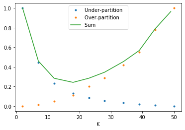

```python
Nvals =  10
Kmax = 50

K1 = get_K_opt(Affinity1, Xtilde1 ,Nvals=Nvals, Kmax=Kmax,output_plots=True )
K2 = get_K_opt(Affinity2, Xtilde2 ,Nvals=Nvals, Kmax=Kmax,output_plots=False )
```

**Fig1** (blue) Under and (orange) over- partition measures estimated for several choice of $K$. Notice that the sum of the two combined presents a minimum at around $K \approx 20$, we choose this value to be the optimal number of clusters for the PySM map.

# Clustering on PySM maps

```python
clusters1 = AgglomerativeClustering(n_clusters=K1 ,affinity= 'precomputed', linkage='average')
clusters1.fit_predict(Affinity1)
clusters2 = AgglomerativeClustering(n_clusters=K2 ,affinity= 'precomputed', linkage='average')
clusters2.fit_predict(Affinity2)
```

```
array([13, 13,  5, ..., 18, 13, 13])
```

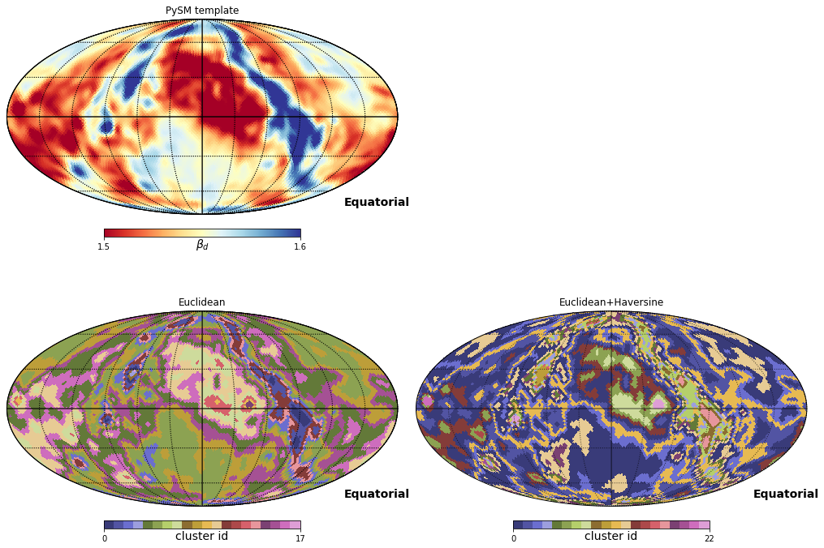

```python
pl.figure(figsize=(14,10))
hp.mollview(r_bdpysm,sub=221, cmap=cmap, unit=r'$\beta_d$', title='PySM template', min=1.5, max=1.6, coord='C');
hp.graticule(alpha=.5, verbose=False)
hp.mollview(clusters1.labels_,sub=223, cmap=cmap2, title='Euclidean', unit='cluster id', coord='C');
hp.graticule(alpha=.7, verbose=False)

hp.mollview(clusters2.labels_,sub=224, cmap=cmap2, title='Euclidean+Haversine', unit='cluster id', coord='C');
hp.graticule(alpha=.7, verbose=False)
```

**Fig2** (top) Map of $\beta_d$ used as a template in the PySM. (bottom left) Cluster map using a Euclidean similarity kernel. (bottom right) Cluster map using a kernel built with both Euclidean and Haversine similarities. Pixels in the map belonging to the same cluster are identified by the same color. Notice that notice that Each color identifies a cluster.

# Clustering on Planck maps

```python
fname_aff='/Users/peppe/work/heavy_maps/affinity_hellinger_nside32_betadust_equatorial.npy'
Xuncertainties= pl.array(  [ ( i,j) for i, j in zip (  r_bd ,r_ebd) ] )     .reshape(len(r_bd),2 )

Xtilde3 , Affinity3  =setup_features(Xuncertainties  , nside , affinity='hellinger' , include_haversine=False,
                                     file_affinity=fname_aff  )
pl.save(fname_aff, Affinity3 )
Xtilde4 , Affinity4  =setup_features(Xuncertainties  , nside ,  affinity='hellinger' ,include_haversine=True,
                                     file_affinity=fname_aff    )
```

```python
Nvals =  10
Kmax = 50

K3 = get_K_opt(Affinity3, Xtilde3 ,Nvals=Nvals, Kmax=Kmax,output_plots=False )
K4 = get_K_opt(Affinity4, Xtilde4 ,Nvals=Nvals, Kmax=Kmax,output_plots=False )
```

```python
clusters3 = AgglomerativeClustering(n_clusters=K3 ,affinity= 'precomputed', linkage='average')
clusters3.fit_predict(Affinity3)
clusters4 = AgglomerativeClustering(n_clusters=K4 ,affinity= 'precomputed', linkage='average')
clusters4.fit_predict(Affinity4)
```

```
array([0, 0, 0, ..., 2, 2, 2])
```

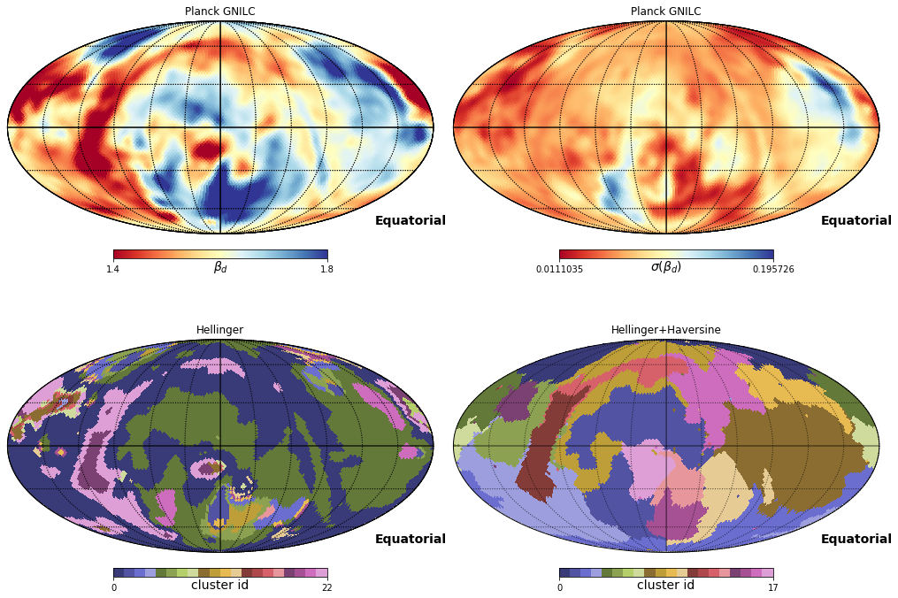

```python
pl.figure(figsize=(14,10))
hp.mollview(r_bd ,sub=221, cmap=cmap, unit=r'$\beta_d$', title='Planck GNILC', min=1.4, max=1.8, coord='C');
hp.graticule(alpha=.5, verbose=False)

hp.mollview(r_ebd ,sub=222, cmap=cmap, unit=r'$\sigma(\beta_d)$', title='Planck GNILC', coord='C');
hp.graticule(alpha=.5, verbose=False)
hp.mollview(clusters3.labels_,sub=223, cmap=cmap2, title='Hellinger', unit='cluster id', coord='C');
hp.graticule(alpha=.7, verbose=False)

hp.mollview(clusters4.labels_,sub=224, cmap=cmap2, title='Hellinger+Haversine', unit='cluster id', coord='C');
hp.graticule(alpha=.7, verbose=False)
```

**Fig3** (top) Map of $\beta_d$ (left) and $\sigma(\beta_d)$ released by Planck. (bottom left) Cluster map using a Hellinger similarity kernel. (bottom right) Cluster map using a kernel built with both Hellinger and Haversine similarities. Pixels in the map belonging to the same cluster are identified by the same color. Notice that notice that Each color identifies a cluster.